# MNIST classification (20 marks):

```python
def train(model, device, train_loader, optimizer, epoch, losses=[], counter=[], errors=[]):
    model.train()
    correct=0
    for batch_idx, (data, target) in enumerate(train_loader):
        data, target = data.to(device), target.to(device)
        optimizer.zero_grad()
        output = model(data)
        loss = F.nll_loss(output, target)
        loss.backward()
        optimizer.step()
        if batch_idx % log_interval == 0:
            print('Train Epoch: {} [{}/{} ({:.0f}%)]\tLoss: {:.6f}'.format(
                epoch, batch_idx * len(data), len(train_loader.dataset),
                100. * batch_idx / len(train_loader), loss.item()))
            losses.append(loss.item())
            counter.append((batch_idx*batch_size) + ((epoch-1)*len(train_loader.dataset)))
        pred = output.max(1, keepdim=True)[1]
        correct += pred.eq(target.view_as(pred)).sum().item()
    errors.append(100. * (1 - correct / len(train_loader.dataset)))

def test(model, device, test_loader, losses=[], errors=[]):
    model.eval()
    test_loss = 0
    correct = 0
    with torch.no_grad():
        for data, target in test_loader:
            data, target = data.to(device), target.to(device)
            output = model(data)
            test_loss += F.nll_loss(output, target, reduction='sum').item() # sum up batch loss
            pred = output.max(1, keepdim=True)[1] # get the index of the max log-probability
            correct += pred.eq(target.view_as(pred)).sum().item()

    test_loss /= len(test_loader.dataset)
    print('\nTest set: Average loss: {:.4f}, Accuracy: {}/{} ({:.0f}%)\n'.format(
        test_loss, correct, len(test_loader.dataset),
        100. * correct / len(test_loader.dataset)))
    losses.append(test_loss)
    errors.append(100. *  (1 - correct / len(test_loader.dataset)))

def calculate_mean_std(dataset):
    mean = 0.0
    for img, _  in dataset:
        mean += img.mean([1,2])
    mean = mean/len(dataset)
    print('images mean {}'.format(mean))

    std = 0.0
    for img, _  in dataset:
        std += torch.mean(img - mean)**2
    std = torch.sqrt(std/len(dataset))
    print('images std {}'.format(std))

    return mean, std

def cifar_loader(use_cuda=False):
    # data transformation
    train_data = datasets.CIFAR10('../data', train=True, download=True,
                   transform=transforms.Compose([
                       transforms.ToTensor()
                   ]))
    test_data = datasets.CIFAR10('../data', train=False,
                   transform=transforms.Compose([
                       transforms.ToTensor()
                   ]))

    # data loaders
    kwargs = {'num_workers': 1, 'pin_memory': True} if use_cuda else {}
    train_loader = torch.utils.data.DataLoader(train_data, batch_size=batch_size, shuffle=True, **kwargs)
    test_loader = torch.utils.data.DataLoader(test_data, batch_size=batch_size, shuffle=False, **kwargs)

    return train_loader, test_loader

def mnist_loader(use_cuda=False):
    # data transformation
    train_data = datasets.MNIST('../data', train=True, download=True,
                   transform=transforms.Compose([
                       transforms.ToTensor(),
                       transforms.Normalize((0.1307,), (0.3081,))
                   ]))
    test_data = datasets.MNIST('../data', train=False,
                   transform=transforms.Compose([
                       transforms.ToTensor(),
                       transforms.Normalize((0.1307,), (0.3081,))
                   ]))

    # data loaders
    kwargs = {'num_workers': 1, 'pin_memory': True} if use_cuda else {}
    train_loader = torch.utils.data.DataLoader(train_data, batch_size=batch_size, shuffle=True, **kwargs)
    test_loader = torch.utils.data.DataLoader(test_data, batch_size=batch_size, shuffle=False, **kwargs)

    return train_loader, test_loader

def fashionmnist_loader(use_cuda=False):
    # data transformation
    train_data = datasets.FashionMNIST('../data', train=True, download=True,
                   transform=transforms.Compose([
                       transforms.ToTensor()
                   ]))
    test_data = datasets.FashionMNIST('../data', train=False,
                   transform=transforms.Compose([
                       transforms.ToTensor()
                   ]))

    mean_train, std_train = calculate_mean_std(train_data)
    mean_test, std_test = calculate_mean_std(test_data)

    train_data.transform = transforms.Compose([
        transforms.ToTensor(),
        transforms.Normalize((mean_train,), (std_train,))
    ])

    test_data.transform = transforms.Compose([
        transforms.ToTensor(),
        transforms.Normalize((mean_test,), (std_test,))
    ])

    # data loaders
    kwargs = {'num_workers': 1, 'pin_memory': True} if use_cuda else {}
    train_loader = torch.utils.data.DataLoader(train_data, batch_size=batch_size, shuffle=True, **kwargs)
    test_loader = torch.utils.data.DataLoader(test_data, batch_size=batch_size, shuffle=False, **kwargs)

    return train_loader, test_loader

def profile_model(model):
    from thop import profile
    input = torch.randn(1,3,32,32)
    flops, params = profile(model, inputs=(input,))
    print('flops {} params count {}'.format(flops, params))

    parameter_count = 0
    for parameter in model.parameters():
        nn = 1
        for s in list(parameter.size()):
            nn *= s
        parameter_count += nn

    print('params count {}'.format(parameter_count))


def main():
    use_cuda = torch.cuda.is_available()
    device = torch.device("cuda" if use_cuda else "cpu")

   # train_loader, test_loader = fashionmnist_loader(use_cuda)
    train_loader, test_loader = mnist_loader(use_cuda)

	# extract and plot random samples of data
    #examples = enumerate(test_loader)
    #batch_idx, (data, target) = next(examples)
    #plot_data(data, target, 'Ground truth')

    # model creation
    model = CNN2().to(device)
    # profile_model(model)
    # optimizer creation
    optimizer = optim.SGD(model.parameters(), lr=learning_rate, momentum=momentum, weight_decay=weight_decay)
```

```
Test set: Average loss: 3.2329, Accuracy: 841/10000 (8%)

Train Epoch: 1 [0/60000 (0%)]	Loss: 3.472961
Train Epoch: 1 [1280/60000 (2%)]	Loss: 1.878621
Train Epoch: 1 [2560/60000 (4%)]	Loss: 0.752342
Train Epoch: 1 [3840/60000 (6%)]	Loss: 0.224995
Train Epoch: 1 [5120/60000 (9%)]	Loss: 0.043232
Train Epoch: 1 [6400/60000 (11%)]	Loss: 0.095769
Train Epoch: 1 [7680/60000 (13%)]	Loss: 0.114747
Train Epoch: 1 [8960/60000 (15%)]	Loss: 0.196831
Train Epoch: 1 [10240/60000 (17%)]	Loss: 0.023645
Train Epoch: 1 [11520/60000 (19%)]	Loss: 0.127129
Train Epoch: 1 [12800/60000 (21%)]	Loss: 0.052735
Train Epoch: 1 [14080/60000 (23%)]	Loss: 0.226182
Train Epoch: 1 [15360/60000 (26%)]	Loss: 0.172057
Train Epoch: 1 [16640/60000 (28%)]	Loss: 0.157883
Train Epoch: 1 [17920/60000 (30%)]	Loss: 0.069503
Train Epoch: 1 [19200/60000 (32%)]	Loss: 0.067304
Train Epoch: 1 [20480/60000 (34%)]	Loss: 0.190319
Train Epoch: 1 [21760/60000 (36%)]	Loss: 0.061311
Train Epoch: 1 [23040/60000 (38%)]	Loss: 0.053705
Train Epoch: 1 [24320/60000 (41%)]	Loss: 0.105027
Train Epoch: 1 [25600/60000 (43%)]	Loss: 0.070028
Train Epoch: 1 [26880/60000 (45%)]	Loss: 0.129634
Train Epoch: 1 [28160/60000 (47%)]	Loss: 0.073730
Train Epoch: 1 [29440/60000 (49%)]	Loss: 0.036809
Train Epoch: 1 [30720/60000 (51%)]	Loss: 0.088240
Train Epoch: 1 [32000/60000 (53%)]	Loss: 0.025471
Train Epoch: 1 [33280/60000 (55%)]	Loss: 0.039110
Train Epoch: 1 [34560/60000 (58%)]	Loss: 0.057436
Train Epoch: 1 [35840/60000 (60%)]	Loss: 0.029362
Train Epoch: 1 [37120/60000 (62%)]	Loss: 0.112335
Train Epoch: 1 [38400/60000 (64%)]	Loss: 0.005088
Train Epoch: 1 [39680/60000 (66%)]	Loss: 0.040573
Train Epoch: 1 [40960/60000 (68%)]	Loss: 0.063632
Train Epoch: 1 [42240/60000 (70%)]	Loss: 0.142175
Train Epoch: 1 [43520/60000 (72%)]	Loss: 0.024860
Train Epoch: 1 [44800/60000 (75%)]	Loss: 0.010107
Train Epoch: 1 [46080/60000 (77%)]	Loss: 0.036663
Train Epoch: 1 [47360/60000 (79%)]	Loss: 0.047762
Train Epoch: 1 [48640/60000 (81%)]	Loss: 0.164438
Train Epoch: 1 [49920/60000 (83%)]	Loss: 0.032082
Train Epoch: 1 [51200/60000 (85%)]	Loss: 0.022518
Train Epoch: 1 [52480/60000 (87%)]	Loss: 0.033140
Train Epoch: 1 [53760/60000 (90%)]	Loss: 0.038959
Train Epoch: 1 [55040/60000 (92%)]	Loss: 0.045149
Train Epoch: 1 [56320/60000 (94%)]	Loss: 0.039146
Train Epoch: 1 [57600/60000 (96%)]	Loss: 0.046984
Train Epoch: 1 [58880/60000 (98%)]	Loss: 0.026976

Test set: Average loss: 0.0522, Accuracy: 9820/10000 (98%)
```

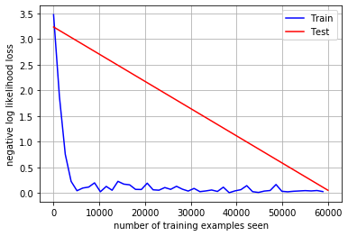

[figure not shown]

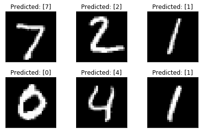

```python
    # lists for saving history
    train_losses = []
    train_counter = []
    test_losses = []
    test_counter = [i*len(train_loader.dataset) for i in range(epochs + 1)]
    train_errors = []
    test_errors = []
    error_counter = [i*len(train_loader.dataset) for i in range(epochs)]

    # test of randomly initialized model
    test(model, device, test_loader, losses=test_losses)

    # global training and testing loop
    for epoch in range(1, epochs + 1):
        train(model, device, train_loader, optimizer, epoch, losses=train_losses, counter=train_counter, errors=train_errors)
        test(model, device, test_loader, losses=test_losses, errors=test_errors)

    # plotting training history
    plot_graph(train_counter, train_losses, test_counter, test_losses, ylabel='negative log likelihood loss')
    plot_graph(error_counter, train_errors, error_counter, test_errors, ylabel='error (%)')

    # extract and plot random samples of data with predicted labels
    data, _, pred = predict_batch(model, device, test_loader)
    plot_data(data, pred, 'Predicted')

if __name__ == '__main__':
    main()
```

# 1c) Change dataset to fashion MNIST (https://research.zalando.com/welcome/mission/researchprojects/fashion-mnist/,hint:

take a look at torchvision.datasets), estimate the dataset mean and standard deviation and use it to normalize the data in the data loader.

```
Mean of MNIST_Fashion Dataset tensor(0.2860)
Standard Deivation of MNIST_Fashion Dataset tensor(0.3530)

Test set: Average loss: 3.3514, Accuracy: 1115/10000 (11%)

Train Epoch: 1 [0/60000 (0%)]	Loss: 3.197839
Train Epoch: 1 [1280/60000 (2%)]	Loss: 0.656894
Train Epoch: 1 [2560/60000 (4%)]	Loss: 0.796756
Train Epoch: 1 [3840/60000 (6%)]	Loss: 0.680090
Train Epoch: 1 [5120/60000 (9%)]	Loss: 0.668203
Train Epoch: 1 [6400/60000 (11%)]	Loss: 0.756833
Train Epoch: 1 [7680/60000 (13%)]	Loss: 0.594097
Train Epoch: 1 [8960/60000 (15%)]	Loss: 0.566547
Train Epoch: 1 [10240/60000 (17%)]	Loss: 0.591104
Train Epoch: 1 [11520/60000 (19%)]	Loss: 0.428682
Train Epoch: 1 [12800/60000 (21%)]	Loss: 0.695401
Train Epoch: 1 [14080/60000 (23%)]	Loss: 0.673725
Train Epoch: 1 [15360/60000 (26%)]	Loss: 0.458929
Train Epoch: 1 [16640/60000 (28%)]	Loss: 0.562531
Train Epoch: 1 [17920/60000 (30%)]	Loss: 0.585959
Train Epoch: 1 [19200/60000 (32%)]	Loss: 0.600329
Train Epoch: 1 [20480/60000 (34%)]	Loss: 0.532234
Train Epoch: 1 [21760/60000 (36%)]	Loss: 0.511914
Train Epoch: 1 [23040/60000 (38%)]	Loss: 0.390124
Train Epoch: 1 [24320/60000 (41%)]	Loss: 0.303754
Train Epoch: 1 [25600/60000 (43%)]	Loss: 0.572177
Train Epoch: 1 [26880/60000 (45%)]	Loss: 0.475437
Train Epoch: 1 [28160/60000 (47%)]	Loss: 0.448188
Train Epoch: 1 [29440/60000 (49%)]	Loss: 0.534596
Train Epoch: 1 [30720/60000 (51%)]	Loss: 0.548311
Train Epoch: 1 [32000/60000 (53%)]	Loss: 0.366973
Train Epoch: 1 [33280/60000 (55%)]	Loss: 0.484224
Train Epoch: 1 [34560/60000 (58%)]	Loss: 0.759214
Train Epoch: 1 [35840/60000 (60%)]	Loss: 0.543146
Train Epoch: 1 [37120/60000 (62%)]	Loss: 0.389424
Train Epoch: 1 [38400/60000 (64%)]	Loss: 0.393265
Train Epoch: 1 [39680/60000 (66%)]	Loss: 0.465324
Train Epoch: 1 [40960/60000 (68%)]	Loss: 0.655763
Train Epoch: 1 [42240/60000 (70%)]	Loss: 0.356665
Train Epoch: 1 [43520/60000 (72%)]	Loss: 0.459140
Train Epoch: 1 [44800/60000 (75%)]	Loss: 0.748206
Train Epoch: 1 [46080/60000 (77%)]	Loss: 0.454825
Train Epoch: 1 [47360/60000 (79%)]	Loss: 0.601323
Train Epoch: 1 [48640/60000 (81%)]	Loss: 0.431674
Train Epoch: 1 [49920/60000 (83%)]	Loss: 0.371037
Train Epoch: 1 [51200/60000 (85%)]	Loss: 0.573894
Train Epoch: 1 [52480/60000 (87%)]	Loss: 0.613898
Train Epoch: 1 [53760/60000 (90%)]	Loss: 0.614098
Train Epoch: 1 [55040/60000 (92%)]	Loss: 0.406938
Train Epoch: 1 [56320/60000 (94%)]	Loss: 0.655300
Train Epoch: 1 [57600/60000 (96%)]	Loss: 0.414596
Train Epoch: 1 [58880/60000 (98%)]	Loss: 0.395357

Test set: Average loss: 0.5099, Accuracy: 8195/10000 (82%)
```

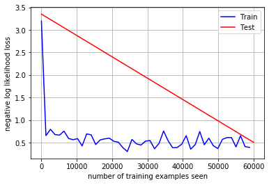

[figure not shown]

[figure not shown]

```python
from __future__ import print_function
import torch
import torch.nn as nn
import torch.nn.functional as F
import torch.optim as optim
from torchvision import datasets, transforms
import matplotlib.pyplot as plt
%matplotlib inline

# Training hyperparameters
epochs = 1
batch_size = 64
learning_rate = 0.02 # TODO
momentum = 0.9
weight_decay = 0.002 # TODO
log_interval = 20

class CNN(nn.Module):
    def __init__(self):
        super(CNN, self).__init__()
        self.conv1 = nn.Conv2d(in_channels=1, out_channels=16,
                               kernel_size=5, stride=1, padding=0)
        self.maxpool = nn.MaxPool2d(2)
        self.conv2 = nn.Conv2d(in_channels=16, out_channels=32,
                               kernel_size=3, stride=1, padding=0)
        self.fc1 = nn.Linear(in_features=800, out_features=128)
        self.fc2 = nn.Linear(in_features=128, out_features=10)

        nn.init.kaiming_normal_(self.conv1.weight, nonlinearity='relu')
        nn.init.kaiming_normal_(self.conv2.weight, nonlinearity='relu')
        nn.init.kaiming_normal_(self.fc1.weight, nonlinearity='relu')
        nn.init.kaiming_normal_(self.fc2.weight, nonlinearity='linear')

    def forward(self, x):
        x = self.conv1(x)
        x = F.relu(x)
        x = self.maxpool(x)
        x = self.conv2(x)
        x = F.relu(x)
        x = self.maxpool(x)
        x = x.view(-1, 800)
        x = self.fc1(x)
        x = F.relu(x)
        x = self.fc2(x)
        return F.log_softmax(x, dim=1)

class CNN2(nn.Module):
    def __init__(self):
        super(CNN2, self).__init__()
        self.conv1 = nn.Conv2d(in_channels=1, out_channels=32,
                               kernel_size=5, stride=1, padding=2)
        self.maxpool = nn.MaxPool2d(2)
        self.conv2 = nn.Conv2d(in_channels=32, out_channels=64,
                               kernel_size=5, stride=1, padding=2)
        self.fc1 = nn.Linear(in_features=3136, out_features=256)
        self.fc2 = nn.Linear(in_features=256, out_features=10)

        nn.init.kaiming_normal_(self.conv1.weight, nonlinearity='relu')
        nn.init.kaiming_normal_(self.conv2.weight, nonlinearity='relu')
        nn.init.kaiming_normal_(self.fc1.weight, nonlinearity='relu')
        nn.init.kaiming_normal_(self.fc2.weight, nonlinearity='linear')

    def forward(self, x):
        x = self.conv1(x)
        x = F.relu(x)
        x = self.maxpool(x)
        x = self.conv2(x)
        x = F.relu(x)
        x = self.maxpool(x)
        x = x.view(-1, 3136)
        x = self.fc1(x)
        x = F.relu(x)
        x = self.fc2(x)
        return F.log_softmax(x, dim=1)

class CNN3(nn.Module):
    def __init__(self):
        super(CNN3, self).__init__()
        # TODO

    def forward(self, x):
        # TODO
        return F.log_softmax(x, dim=1)

def plot_data(data, label, text):
    fig = plt.figure()
    for i in range(6):
        plt.subplot(2,3,i+1)
        plt.tight_layout()
        plt.imshow(data[i][0], cmap='gray', interpolation='none')
        plt.title(text + ": {}".format(label[i]))
        plt.xticks([])
        plt.yticks([])
    plt.show()

def predict_batch(model, device, test_loader):
    examples = enumerate(test_loader)
    model.eval()
    with torch.no_grad():
        batch_idx, (data, target) = next(examples)
        data, target = data.to(device), target.to(device)
        output = model(data)
        pred = output.cpu().data.max(1, keepdim=True)[1] # get the index of the max log-probability
        pred = pred.numpy()
    return data.cpu().data.numpy(), target.cpu().data.numpy(), pred

def plot_graph(train_x, train_y, test_x, test_y, ylabel=''):
    fig = plt.figure()
    plt.plot(train_x, train_y, color='blue')
    plt.plot(test_x, test_y, color='red')
    plt.legend(['Train', 'Test'], loc='upper right')
    plt.xlabel('number of training examples seen')
    plt.ylabel(ylabel)
    plt.grid()
    plt.show()

def train(model, device, train_loader, optimizer, epoch, losses=[], counter=[], errors=[]):
    model.train()
    correct=0
    for batch_idx, (data, target) in enumerate(train_loader):
        data, target = data.to(device), target.to(device)
        optimizer.zero_grad()
        output = model(data)
        loss = F.nll_loss(output, target)
        loss.backward()
        optimizer.step()
        if batch_idx % log_interval == 0:
            print('Train Epoch: {} [{}/{} ({:.0f}%)]\tLoss: {:.6f}'.format(
                epoch, batch_idx * len(data), len(train_loader.dataset),
                100. * batch_idx / len(train_loader), loss.item()))
            losses.append(loss.item())
            counter.append((batch_idx*batch_size) + ((epoch-1)*len(train_loader.dataset)))
        pred = output.max(1, keepdim=True)[1]
        correct += pred.eq(target.view_as(pred)).sum().item()
    errors.append(100. * (1 - correct / len(train_loader.dataset)))

def test(model, device, test_loader, losses=[], errors=[]):
    model.eval()
    test_loss = 0
    correct = 0
    with torch.no_grad():
        for data, target in test_loader:
            data, target = data.to(device), target.to(device)
            output = model(data)
            test_loss += F.nll_loss(output, target, reduction='sum').item() # sum up batch loss
            pred = output.max(1, keepdim=True)[1] # get the index of the max log-probability
            correct += pred.eq(target.view_as(pred)).sum().item()

    test_loss /= len(test_loader.dataset)
    print('\nTest set: Average loss: {:.4f}, Accuracy: {}/{} ({:.0f}%)\n'.format(
        test_loss, correct, len(test_loader.dataset),
        100. * correct / len(test_loader.dataset)))
    losses.append(test_loss)
    errors.append(100. *  (1 - correct / len(test_loader.dataset)))

def main():
    use_cuda = torch.cuda.is_available()
    device = torch.device("cuda" if use_cuda else "cpu")

    # data transformation
    train_data = datasets.FashionMNIST('../data', train=True, download=True,
                   transform=transforms.Compose([
                       transforms.ToTensor(),
                       transforms.Normalize((0.2860,), (0.3530,))
                   ]))
    test_data = datasets.FashionMNIST('../data', train=False,
                   transform=transforms.Compose([
                       transforms.ToTensor(),
                       transforms.Normalize((0.2860,), (0.3530,))
                   ]))

    #Mean and Standard Deviation for MNIST_Fashion
    print("Mean of MNIST_Fashion Dataset",train_data.data.float().mean()/255)
    print("Standard Deivation of MNIST_Fashion Dataset",train_data.data.float().std()/255)

    # data loaders
    kwargs = {'num_workers': 1, 'pin_memory': True} if use_cuda else {}
    train_loader = torch.utils.data.DataLoader(train_data, batch_size=batch_size, shuffle=True, **kwargs)
    test_loader = torch.utils.data.DataLoader(test_data, batch_size=batch_size, shuffle=False, **kwargs)

	# extract and plot random samples of data
    #examples = enumerate(test_loader)
    #batch_idx, (data, target) = next(examples)
    #plot_data(data, target, 'Ground truth')

    # model creation
    model = CNN2().to(device)
    # optimizer creation
    optimizer = optim.SGD(model.parameters(), lr=learning_rate, momentum=momentum, weight_decay=weight_decay)

    # lists for saving history
    train_losses = []
    train_counter = []
    test_losses = []
    test_counter = [i*len(train_loader.dataset) for i in range(epochs + 1)]
    train_errors = []
    test_errors = []
    error_counter = [i*len(train_loader.dataset) for i in range(epochs)]

    # test of randomly initialized model
    test(model, device, test_loader, losses=test_losses)

    # global training and testing loop
    for epoch in range(1, epochs + 1):
        train(model, device, train_loader, optimizer, epoch, losses=train_losses, counter=train_counter, errors=train_errors)
        test(model, device, test_loader, losses=test_losses, errors=test_errors)

    # plotting training history
    plot_graph(train_counter, train_losses, test_counter, test_losses, ylabel='negative log likelihood loss')
    plot_graph(error_counter, train_errors, error_counter, test_errors, ylabel='error (%)')

    # extract and plot random samples of data with predicted labels
    data, _, pred = predict_batch(model, device, test_loader)
    plot_data(data, pred, 'Predicted')

if __name__ == '__main__':
    main()
```

# 1d) Design CNN3 with additional regularization of your choosing. Explain benefits of such regularization and report its accurracy on fashion MNIST and its relative improvement over CNN2.

```
Mean of MNIST_Fashion Dataset tensor(0.2860)
Standard Deivation of MNIST_Fashion Dataset tensor(0.3530)

Test set: Average loss: 3.2696, Accuracy: 918/10000 (9%)

Train Epoch: 1 [0/60000 (0%)]	Loss: 4.680375
Train Epoch: 1 [1280/60000 (2%)]	Loss: 1.120182
Train Epoch: 1 [2560/60000 (4%)]	Loss: 0.637148
Train Epoch: 1 [3840/60000 (6%)]	Loss: 0.660683
Train Epoch: 1 [5120/60000 (9%)]	Loss: 0.787009
Train Epoch: 1 [6400/60000 (11%)]	Loss: 0.389360
Train Epoch: 1 [7680/60000 (13%)]	Loss: 0.587845
Train Epoch: 1 [8960/60000 (15%)]	Loss: 0.553284
Train Epoch: 1 [10240/60000 (17%)]	Loss: 0.336184
Train Epoch: 1 [11520/60000 (19%)]	Loss: 0.508436
Train Epoch: 1 [12800/60000 (21%)]	Loss: 0.370370
Train Epoch: 1 [14080/60000 (23%)]	Loss: 0.455044
Train Epoch: 1 [15360/60000 (26%)]	Loss: 0.361029
Train Epoch: 1 [16640/60000 (28%)]	Loss: 0.318575
Train Epoch: 1 [17920/60000 (30%)]	Loss: 0.426002
Train Epoch: 1 [19200/60000 (32%)]	Loss: 0.430551
Train Epoch: 1 [20480/60000 (34%)]	Loss: 0.543784
Train Epoch: 1 [21760/60000 (36%)]	Loss: 0.356414
Train Epoch: 1 [23040/60000 (38%)]	Loss: 0.431497
Train Epoch: 1 [24320/60000 (41%)]	Loss: 0.345604
Train Epoch: 1 [25600/60000 (43%)]	Loss: 0.576607
Train Epoch: 1 [26880/60000 (45%)]	Loss: 0.538058
Train Epoch: 1 [28160/60000 (47%)]	Loss: 0.420743
Train Epoch: 1 [29440/60000 (49%)]	Loss: 0.408570
Train Epoch: 1 [30720/60000 (51%)]	Loss: 0.240143
Train Epoch: 1 [32000/60000 (53%)]	Loss: 0.539456
Train Epoch: 1 [33280/60000 (55%)]	Loss: 0.388251
Train Epoch: 1 [34560/60000 (58%)]	Loss: 0.275375
Train Epoch: 1 [35840/60000 (60%)]	Loss: 0.310973
Train Epoch: 1 [37120/60000 (62%)]	Loss: 0.273212
Train Epoch: 1 [38400/60000 (64%)]	Loss: 0.258549
Train Epoch: 1 [39680/60000 (66%)]	Loss: 0.541942
Train Epoch: 1 [40960/60000 (68%)]	Loss: 0.368330
Train Epoch: 1 [42240/60000 (70%)]	Loss: 0.340213
Train Epoch: 1 [43520/60000 (72%)]	Loss: 0.302265
Train Epoch: 1 [44800/60000 (75%)]	Loss: 0.193338
Train Epoch: 1 [46080/60000 (77%)]	Loss: 0.253674
Train Epoch: 1 [47360/60000 (79%)]	Loss: 0.585120
Train Epoch: 1 [48640/60000 (81%)]	Loss: 0.438302
Train Epoch: 1 [49920/60000 (83%)]	Loss: 0.376977
Train Epoch: 1 [51200/60000 (85%)]	Loss: 0.325911
Train Epoch: 1 [52480/60000 (87%)]	Loss: 0.369176
Train Epoch: 1 [53760/60000 (90%)]	Loss: 0.218646
Train Epoch: 1 [55040/60000 (92%)]	Loss: 0.369276
Train Epoch: 1 [56320/60000 (94%)]	Loss: 0.377028
Train Epoch: 1 [57600/60000 (96%)]	Loss: 0.515554
Train Epoch: 1 [58880/60000 (98%)]	Loss: 0.403597

Test set: Average loss: 0.4071, Accuracy: 8620/10000 (86%)
```

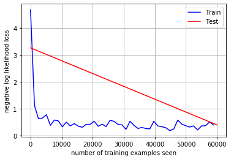

[figure not shown]

[figure not shown]

```python
from __future__ import print_function
import torch
import torch.nn as nn
import torch.nn.functional as F
import torch.optim as optim
from torchvision import datasets, transforms
import matplotlib.pyplot as plt
%matplotlib inline

# Training hyperparameters
epochs = 1
batch_size = 64
learning_rate = 0.02 # TODO
momentum = 0.9
weight_decay = 0.002 # TODO
log_interval = 20

class CNN(nn.Module):
    def __init__(self):
        super(CNN, self).__init__()
        self.conv1 = nn.Conv2d(in_channels=1, out_channels=16,
                               kernel_size=5, stride=1, padding=0)
        self.maxpool = nn.MaxPool2d(2)
        self.conv2 = nn.Conv2d(in_channels=16, out_channels=32,
                               kernel_size=3, stride=1, padding=0)
        self.fc1 = nn.Linear(in_features=800, out_features=128)
        self.fc2 = nn.Linear(in_features=128, out_features=10)

        nn.init.kaiming_normal_(self.conv1.weight, nonlinearity='relu')
        nn.init.kaiming_normal_(self.conv2.weight, nonlinearity='relu')
        nn.init.kaiming_normal_(self.fc1.weight, nonlinearity='relu')
        nn.init.kaiming_normal_(self.fc2.weight, nonlinearity='linear')

    def forward(self, x):
        x = self.conv1(x)
        x = F.relu(x)
        x = self.maxpool(x)
        x = self.conv2(x)
        x = F.relu(x)
        x = self.maxpool(x)
        x = x.view(-1, 800)
        x = self.fc1(x)
        x = F.relu(x)
        x = self.fc2(x)
        return F.log_softmax(x, dim=1)

class CNN2(nn.Module):
    def __init__(self):
        super(CNN2, self).__init__()
        self.conv1 = nn.Conv2d(in_channels=1, out_channels=32,
                               kernel_size=5, stride=1, padding=2)
        self.maxpool = nn.MaxPool2d(2)
        self.conv2 = nn.Conv2d(in_channels=32, out_channels=64,
                               kernel_size=5, stride=1, padding=2)
        self.fc1 = nn.Linear(in_features=3136, out_features=256)
        self.fc2 = nn.Linear(in_features=256, out_features=10)

        nn.init.kaiming_normal_(self.conv1.weight, nonlinearity='relu')
        nn.init.kaiming_normal_(self.conv2.weight, nonlinearity='relu')
        nn.init.kaiming_normal_(self.fc1.weight, nonlinearity='relu')
        nn.init.kaiming_normal_(self.fc2.weight, nonlinearity='linear')

    def forward(self, x):
        x = self.conv1(x)
        x = F.relu(x)
        x = self.maxpool(x)
        x = self.conv2(x)
        x = F.relu(x)
        x = self.maxpool(x)
        x = x.view(-1, 3136)
        x = self.fc1(x)
        x = F.relu(x)
        x = self.fc2(x)
        return F.log_softmax(x, dim=1)

class CNN3(nn.Module):
    def __init__(self):
        super(CNN3, self).__init__()
        self.conv1 = nn.Conv2d(in_channels=1, out_channels=32,
                               kernel_size=5, stride=1, padding=2)
        self.dropout1=nn.Dropout(0.5)
        self.maxpool = nn.MaxPool2d(2)
        self.conv2 = nn.Conv2d(in_channels=32, out_channels=64,
                               kernel_size=5, stride=1, padding=2)
        self.fc1 = nn.Linear(in_features=3136, out_features=256)
        self.fc2 = nn.Linear(in_features=256, out_features=10)

        nn.init.kaiming_normal_(self.conv1.weight, nonlinearity='relu')
        nn.init.kaiming_normal_(self.conv2.weight, nonlinearity='relu')
        nn.init.kaiming_normal_(self.fc1.weight, nonlinearity='relu')
        nn.init.kaiming_normal_(self.fc2.weight, nonlinearity='linear')

    def forward(self, x):
        x = self.conv1(x)
        x = F.relu(x)
        x = self.dropout1(x)
        x = self.maxpool(x)
        x = self.conv2(x)
        x = F.relu(x)
        x = self.maxpool(x)
        x = x.view(-1, 3136)
        x = self.fc1(x)
        x = F.relu(x)
        x = self.fc2(x)
        return F.log_softmax(x, dim=1)

def plot_data(data, label, text):
    fig = plt.figure()
    for i in range(6):
        plt.subplot(2,3,i+1)
        plt.tight_layout()
        plt.imshow(data[i][0], cmap='gray', interpolation='none')
        plt.title(text + ": {}".format(label[i]))
        plt.xticks([])
        plt.yticks([])
    plt.show()

def predict_batch(model, device, test_loader):
    examples = enumerate(test_loader)
    model.eval()
    with torch.no_grad():
        batch_idx, (data, target) = next(examples)
        data, target = data.to(device), target.to(device)
        output = model(data)
        pred = output.cpu().data.max(1, keepdim=True)[1] # get the index of the max log-probability
        pred = pred.numpy()
    return data.cpu().data.numpy(), target.cpu().data.numpy(), pred

def plot_graph(train_x, train_y, test_x, test_y, ylabel=''):
    fig = plt.figure()
    plt.plot(train_x, train_y, color='blue')
    plt.plot(test_x, test_y, color='red')
    plt.legend(['Train', 'Test'], loc='upper right')
    plt.xlabel('number of training examples seen')
    plt.ylabel(ylabel)
    plt.grid()
    plt.show()

def train(model, device, train_loader, optimizer, epoch, losses=[], counter=[], errors=[]):
    model.train()
    correct=0
    for batch_idx, (data, target) in enumerate(train_loader):
        data, target = data.to(device), target.to(device)
        optimizer.zero_grad()
        output = model(data)
        loss = F.nll_loss(output, target)
        loss.backward()
        optimizer.step()
        if batch_idx % log_interval == 0:
            print('Train Epoch: {} [{}/{} ({:.0f}%)]\tLoss: {:.6f}'.format(
                epoch, batch_idx * len(data), len(train_loader.dataset),
                100. * batch_idx / len(train_loader), loss.item()))
            losses.append(loss.item())
            counter.append((batch_idx*batch_size) + ((epoch-1)*len(train_loader.dataset)))
        pred = output.max(1, keepdim=True)[1]
        correct += pred.eq(target.view_as(pred)).sum().item()
    errors.append(100. * (1 - correct / len(train_loader.dataset)))

def test(model, device, test_loader, losses=[], errors=[]):
    model.eval()
    test_loss = 0
    correct = 0
    with torch.no_grad():
        for data, target in test_loader:
            data, target = data.to(device), target.to(device)
            output = model(data)
            test_loss += F.nll_loss(output, target, reduction='sum').item() # sum up batch loss
            pred = output.max(1, keepdim=True)[1] # get the index of the max log-probability
            correct += pred.eq(target.view_as(pred)).sum().item()

    test_loss /= len(test_loader.dataset)
    print('\nTest set: Average loss: {:.4f}, Accuracy: {}/{} ({:.0f}%)\n'.format(
        test_loss, correct, len(test_loader.dataset),
        100. * correct / len(test_loader.dataset)))
    losses.append(test_loss)
    errors.append(100. *  (1 - correct / len(test_loader.dataset)))

def main():
    use_cuda = torch.cuda.is_available()
    device = torch.device("cuda" if use_cuda else "cpu")

    # data transformation
    train_data = datasets.FashionMNIST('../data', train=True, download=True,
                   transform=transforms.Compose([
                       transforms.ToTensor(),
                       transforms.Normalize((0.2860,), (0.3530,))
                   ]))
    test_data = datasets.FashionMNIST('../data', train=False,
                   transform=transforms.Compose([
                       transforms.ToTensor(),
                       transforms.Normalize((0.2860,), (0.3530,))
                   ]))

    #Mean and Standard Deviation for MNIST_Fashion
    print("Mean of MNIST_Fashion Dataset",train_data.data.float().mean()/255)
    print("Standard Deivation of MNIST_Fashion Dataset",train_data.data.float().std()/255)

    # data loaders
    kwargs = {'num_workers': 1, 'pin_memory': True} if use_cuda else {}
    train_loader = torch.utils.data.DataLoader(train_data, batch_size=batch_size, shuffle=True, **kwargs)
    test_loader = torch.utils.data.DataLoader(test_data, batch_size=batch_size, shuffle=False, **kwargs)

	# extract and plot random samples of data
    #examples = enumerate(test_loader)
    #batch_idx, (data, target) = next(examples)
    #plot_data(data, target, 'Ground truth')

    # model creation
    model = CNN3().to(device)
    # optimizer creation
    optimizer = optim.SGD(model.parameters(), lr=learning_rate, momentum=momentum, weight_decay=weight_decay)

    # lists for saving history
    train_losses = []
    train_counter = []
    test_losses = []
    test_counter = [i*len(train_loader.dataset) for i in range(epochs + 1)]
    train_errors = []
    test_errors = []
    error_counter = [i*len(train_loader.dataset) for i in range(epochs)]

    # test of randomly initialized model
    test(model, device, test_loader, losses=test_losses)

    # global training and testing loop
    for epoch in range(1, epochs + 1):
        train(model, device, train_loader, optimizer, epoch, losses=train_losses, counter=train_counter, errors=train_errors)
        test(model, device, test_loader, losses=test_losses, errors=test_errors)

    # plotting training history
    plot_graph(train_counter, train_losses, test_counter, test_losses, ylabel='negative log likelihood loss')
    plot_graph(error_counter, train_errors, error_counter, test_errors, ylabel='error (%)')

    # extract and plot random samples of data with predicted labels
    data, _, pred = predict_batch(model, device, test_loader)
    plot_data(data, pred, 'Predicted')

if __name__ == '__main__':
    main()
```

# Regularization - dropout

# 1e) Download file YourEmail_in.csv from the course drive. File contains 5x5 array of integers X. Manualy compute valid convolution

-> vikumar@tcd.ie_out.csv

# 1f) Download file YourEmail_network.csv from the course drive. File contains network definiton in the following format:

i) Convolution, N, K – convolution layer with N feature maps and KxK filters ii) Maxpool, K – max pooling layer KxK pooling window iii) Fully-connected, N – fully connected layer with N neurons

->vikumar@tcd.ie_params.csv

# 2 Image denoising

# 2.a) Briefly explain how the authors have decided on the particular network depth. Which tasks is the DnCNN-3 designed to solve?

The researcher has treated image denoising as learning problem where the noise is separated from noisy image which is feed to forward CNN. There are three points considered while using CNN. First, CNN with very deep architecture effectively increase the capacity and flexibility for exploiting image characteristics. Adjusting the right depth gives the model best efficiency and performance. The denoising neural network depends on selecting the patch size. Higher noise requires larger effective patch size to capture more information.Secondly, regularization and learning methods for training CNN is used to get better accuracy which are Rectifier Linear Unit (ReLU), batch normalization and residual learning. It will speed up the process and improve denoising performance. Third, CNN is well suited for parallel computation with GPU to improve the run time performance. It is also possible to run train a single CNN model for general image denoising tasks like Gaussian denoising, blind Gaussian, SISR with multiple upscaling factors, and JPEG deblocking with different quality factors.

# b) Use main_test.py to test the pretrained model on denoising the whole Set68 with σ=25 and report the obtained average PSNR and SSIM metrics. Download YourEmail_sigma.csv that contains specific value of σ. Test the same model on the same set corrupted by this particular σ and report the results.

```python
# -*- coding: utf-8 -*-

# =============================================================================
#  @article{zhang2017beyond,
#    title={Beyond a {Gaussian} denoiser: Residual learning of deep {CNN} for image denoising},
#    author={Zhang, Kai and Zuo, Wangmeng and Chen, Yunjin and Meng, Deyu and Zhang, Lei},
#    journal={IEEE Transactions on Image Processing},
#    year={2017},
#    volume={26},
#    number={7},
#    pages={3142-3155},
#  }
# modified version of the code from https://github.com/cszn/DnCNN
# =============================================================================

# run this to test the model

import argparse
import os, time, datetime
import numpy as np
import torch.nn as nn
import torch.nn.init as init
import torch
from skimage.measure import compare_psnr, compare_ssim
from skimage.io import imread, imsave
import warnings
warnings.filterwarnings('ignore')


def parse_args():
    parser = argparse.ArgumentParser()
    parser.add_argument('--set_dir', default='data/Test', type=str, help='directory of test dataset')
    parser.add_argument('--set_names', default=['Set68'], help='directory of test dataset')
    parser.add_argument('--sigma', default=25, type=int, help='noise level')
    parser.add_argument('--model_path', default='models/model_000.pth', type=str, help='the model name')
    parser.add_argument('--result_dir', default='results', type=str, help='directory of test dataset')
    parser.add_argument('--save_result', action='store_true', help='save the denoised image')
    return parser.parse_args([])


def log(*args, **kwargs):
     print(datetime.datetime.now().strftime("%Y-%m-%d %H:%M:%S:"), *args, **kwargs)


def save_result(result, path):
    path = path if path.find('.') != -1 else path+'.png'
    ext = os.path.splitext(path)[-1]
    if ext in ('.txt', '.dlm'):
        np.savetxt(path, result, fmt='%2.4f')
    else:
        imsave(path, np.uint8(np.clip(result*255.0, 0, 255)))


def show(x, title=None, cbar=False, figsize=None):
    import matplotlib.pyplot as plt
    plt.figure(figsize=figsize)
    plt.imshow(x, interpolation='nearest', cmap='gray')
    if title:
        plt.title(title)
    if cbar:
        plt.colorbar()
    plt.show()


class DnCNN(nn.Module):

    def __init__(self, depth=17, n_channels=64, image_channels=1, use_bnorm=True, kernel_size=3):
        super(DnCNN, self).__init__()
        kernel_size = 3
        padding = 1
        layers = []
        layers.append(nn.Conv2d(in_channels=image_channels, out_channels=n_channels, kernel_size=kernel_size, padding=padding, bias=True))
        layers.append(nn.ReLU(inplace=True))
        for _ in range(depth-2):
            layers.append(nn.Conv2d(in_channels=n_channels, out_channels=n_channels, kernel_size=kernel_size, padding=padding, bias=False))
            layers.append(nn.BatchNorm2d(n_channels))
            layers.append(nn.ReLU(inplace=True))
        layers.append(nn.Conv2d(in_channels=n_channels, out_channels=image_channels, kernel_size=kernel_size, padding=padding, bias=False))
        self.dncnn = nn.Sequential(*layers)
        self._initialize_weights()

    def forward(self, x):
        y = x
        out = self.dncnn(x)
        return y-out

    def _initialize_weights(self):
        for m in self.modules():
            if isinstance(m, nn.Conv2d):
                init.orthogonal_(m.weight)
                print('init weight')
                if m.bias is not None:
                    init.constant_(m.bias, 0)
            elif isinstance(m, nn.BatchNorm2d):
                init.constant_(m.weight, 1)
                init.constant_(m.bias, 0)


if __name__ == '__main__':

    args = parse_args()

    model = torch.load(args.model_path)
    log('load trained model')

    model.eval()  # evaluation mode

    if torch.cuda.is_available():
        model = model.cuda()

    if not os.path.exists(args.result_dir):
        os.mkdir(args.result_dir)

    for set_cur in args.set_names:

        if not os.path.exists(os.path.join(args.result_dir, set_cur)):
            os.mkdir(os.path.join(args.result_dir, set_cur))
        psnrs = []
        ssims = []

        for im in os.listdir(os.path.join(args.set_dir, set_cur)):
            if im.endswith(".jpg") or im.endswith(".bmp") or im.endswith(".png"):

                x = np.array(imread(os.path.join(args.set_dir, set_cur, im)), dtype=np.float32)/255.0
                np.random.seed(seed=0)  # for reproducibility
                y = x + np.random.normal(0, args.sigma/255.0, x.shape)  # Add Gaussian noise without clipping
                y = y.astype(np.float32)
                y_ = torch.from_numpy(y).view(1, -1, y.shape[0], y.shape[1])

                torch.cuda.synchronize()
                start_time = time.time()
                y_ = y_.cuda()
                x_ = model(y_)  # inference
                x_ = x_.view(y.shape[0], y.shape[1])
                x_ = x_.cpu()
                x_ = x_.detach().numpy().astype(np.float32)
                torch.cuda.synchronize()
                elapsed_time = time.time() - start_time
                print('%10s : %10s : %2.4f second' % (set_cur, im, elapsed_time))

                psnr_x_ = compare_psnr(x, x_)
                ssim_x_ = compare_ssim(x, x_)
                if args.save_result:
                    name, ext = os.path.splitext(im)
                    #show(np.hstack((y, x_)))  # show the image
                    save_result(x_, path=os.path.join(args.result_dir, set_cur, name+'_dncnn'+ext))  # save the denoised image
                psnrs.append(psnr_x_)
                ssims.append(ssim_x_)
        psnr_avg = np.mean(psnrs)
        ssim_avg = np.mean(ssims)
        psnrs.append(psnr_avg)
        ssims.append(ssim_avg)
        if args.save_result:
            save_result(np.hstack((psnrs, ssims)), path=os.path.join(args.result_dir, set_cur, 'results.txt'))
        log('Datset: {0:10s} \n  PSNR = {1:2.2f}dB, SSIM = {2:1.4f}'.format(set_cur, psnr_avg, ssim_avg))
```

```
2019-11-24 12:45:58: load trained model
     Set68 : test001.png : 6.9369 second
     Set68 : test002.png : 0.0312 second
     Set68 : test003.png : 0.0469 second
     Set68 : test004.png : 0.0469 second
     Set68 : test005.png : 0.0469 second
     Set68 : test006.png : 0.0469 second
     Set68 : test007.png : 0.0312 second
     Set68 : test008.png : 0.0469 second
     Set68 : test009.png : 0.0469 second
     Set68 : test010.png : 0.0469 second
     Set68 : test011.png : 0.0312 second
     Set68 : test012.png : 0.0469 second
     Set68 : test013.png : 0.0469 second
     Set68 : test014.png : 0.0312 second
     Set68 : test015.png : 0.0469 second
     Set68 : test016.png : 0.0312 second
     Set68 : test017.png : 0.0469 second
     Set68 : test018.png : 0.0312 second
     Set68 : test019.png : 0.0312 second
     Set68 : test020.png : 0.0312 second
     Set68 : test021.png : 0.0469 second
     Set68 : test022.png : 0.0312 second
     Set68 : test023.png : 0.0469 second
     Set68 : test024.png : 0.0312 second
     Set68 : test025.png : 0.0469 second
     Set68 : test026.png : 0.0469 second
     Set68 : test027.png : 0.0312 second
     Set68 : test028.png : 0.0312 second
     Set68 : test029.png : 0.0469 second
     Set68 : test030.png : 0.0469 second
     Set68 : test031.png : 0.0312 second
     Set68 : test032.png : 0.0469 second
     Set68 : test033.png : 0.0312 second
     Set68 : test034.png : 0.0469 second
     Set68 : test035.png : 0.0469 second
     Set68 : test036.png : 0.0312 second
     Set68 : test037.png : 0.0469 second
     Set68 : test038.png : 0.0469 second
     Set68 : test039.png : 0.0312 second
```

[output cut: 16 more lines]

```
     Set68 : test056.png : 0.0469 second
     Set68 : test057.png : 0.0469 second
     Set68 : test058.png : 0.0312 second
     Set68 : test059.png : 0.0469 second
     Set68 : test060.png : 0.0312 second
     Set68 : test061.png : 0.0469 second
     Set68 : test062.png : 0.0469 second
     Set68 : test063.png : 0.0469 second
     Set68 : test064.png : 0.0312 second
     Set68 : test065.png : 0.0469 second
     Set68 : test066.png : 0.0469 second
     Set68 : test067.png : 0.0312 second
     Set68 : test068.png : 0.0469 second
2019-11-24 12:46:10: Datset: Set68
  PSNR = 29.26dB, SSIM = 0.9022
```

# With sigma value - 47

```python
# -*- coding: utf-8 -*-

# =============================================================================
#  @article{zhang2017beyond,
#    title={Beyond a {Gaussian} denoiser: Residual learning of deep {CNN} for image denoising},
#    author={Zhang, Kai and Zuo, Wangmeng and Chen, Yunjin and Meng, Deyu and Zhang, Lei},
#    journal={IEEE Transactions on Image Processing},
#    year={2017},
#    volume={26},
#    number={7},
#    pages={3142-3155},
#  }
# modified version of the code from https://github.com/cszn/DnCNN
# =============================================================================

# run this to test the model

import argparse
import os, time, datetime
import numpy as np
import torch.nn as nn
import torch.nn.init as init
import torch
from skimage.measure import compare_psnr, compare_ssim
from skimage.io import imread, imsave
import warnings
warnings.filterwarnings('ignore')


def parse_args():
    parser = argparse.ArgumentParser()
    parser.add_argument('--set_dir', default='data/Test', type=str, help='directory of test dataset')
    parser.add_argument('--set_names', default=['Set68'], help='directory of test dataset')
    parser.add_argument('--sigma', default=47, type=int, help='noise level')
    parser.add_argument('--model_path', default='models/model_000.pth', type=str, help='the model name')
    parser.add_argument('--result_dir', default='results', type=str, help='directory of test dataset')
    parser.add_argument('--save_result', action='store_true', help='save the denoised image')
    return parser.parse_args([])


def log(*args, **kwargs):
     print(datetime.datetime.now().strftime("%Y-%m-%d %H:%M:%S:"), *args, **kwargs)


def save_result(result, path):
    path = path if path.find('.') != -1 else path+'.png'
    ext = os.path.splitext(path)[-1]
    if ext in ('.txt', '.dlm'):
        np.savetxt(path, result, fmt='%2.4f')
    else:
        imsave(path, np.uint8(np.clip(result*255.0, 0, 255)))


def show(x, title=None, cbar=False, figsize=None):
    import matplotlib.pyplot as plt
    plt.figure(figsize=figsize)
    plt.imshow(x, interpolation='nearest', cmap='gray')
    if title:
        plt.title(title)
    if cbar:
        plt.colorbar()
    plt.show()


class DnCNN(nn.Module):

    def __init__(self, depth=17, n_channels=64, image_channels=1, use_bnorm=True, kernel_size=3):
        super(DnCNN, self).__init__()
        kernel_size = 3
        padding = 1
        layers = []
        layers.append(nn.Conv2d(in_channels=image_channels, out_channels=n_channels, kernel_size=kernel_size, padding=padding, bias=True))
        layers.append(nn.ReLU(inplace=True))
        for _ in range(depth-2):
            layers.append(nn.Conv2d(in_channels=n_channels, out_channels=n_channels, kernel_size=kernel_size, padding=padding, bias=False))
            layers.append(nn.BatchNorm2d(n_channels))
            layers.append(nn.ReLU(inplace=True))
        layers.append(nn.Conv2d(in_channels=n_channels, out_channels=image_channels, kernel_size=kernel_size, padding=padding, bias=False))
        self.dncnn = nn.Sequential(*layers)
        self._initialize_weights()

    def forward(self, x):
        y = x
        out = self.dncnn(x)
        return y-out

    def _initialize_weights(self):
        for m in self.modules():
            if isinstance(m, nn.Conv2d):
                init.orthogonal_(m.weight)
                print('init weight')
                if m.bias is not None:
                    init.constant_(m.bias, 0)
            elif isinstance(m, nn.BatchNorm2d):
                init.constant_(m.weight, 1)
                init.constant_(m.bias, 0)


if __name__ == '__main__':

    args = parse_args()

    model = torch.load(args.model_path)
    log('load trained model')

    model.eval()  # evaluation mode

    if torch.cuda.is_available():
        model = model.cuda()

    if not os.path.exists(args.result_dir):
        os.mkdir(args.result_dir)

    for set_cur in args.set_names:

        if not os.path.exists(os.path.join(args.result_dir, set_cur)):
            os.mkdir(os.path.join(args.result_dir, set_cur))
        psnrs = []
        ssims = []

        for im in os.listdir(os.path.join(args.set_dir, set_cur)):
            if im.endswith(".jpg") or im.endswith(".bmp") or im.endswith(".png"):

                x = np.array(imread(os.path.join(args.set_dir, set_cur, im)), dtype=np.float32)/255.0
                np.random.seed(seed=0)  # for reproducibility
                y = x + np.random.normal(0, args.sigma/255.0, x.shape)  # Add Gaussian noise without clipping
                y = y.astype(np.float32)
                y_ = torch.from_numpy(y).view(1, -1, y.shape[0], y.shape[1])

                torch.cuda.synchronize()
                start_time = time.time()
                y_ = y_.cuda()
                x_ = model(y_)  # inference
                x_ = x_.view(y.shape[0], y.shape[1])
                x_ = x_.cpu()
                x_ = x_.detach().numpy().astype(np.float32)
                torch.cuda.synchronize()
                elapsed_time = time.time() - start_time
                print('%10s : %10s : %2.4f second' % (set_cur, im, elapsed_time))

                psnr_x_ = compare_psnr(x, x_)
                ssim_x_ = compare_ssim(x, x_)
                if args.save_result:
                    name, ext = os.path.splitext(im)
                    #show(np.hstack((y, x_)))  # show the image
                    save_result(x_, path=os.path.join(args.result_dir, set_cur, name+'_dncnn'+ext))  # save the denoised image
                psnrs.append(psnr_x_)
                ssims.append(ssim_x_)
        psnr_avg = np.mean(psnrs)
        ssim_avg = np.mean(ssims)
        psnrs.append(psnr_avg)
        ssims.append(ssim_avg)
        if args.save_result:
            save_result(np.hstack((psnrs, ssims)), path=os.path.join(args.result_dir, set_cur, 'results.txt'))
        log('Datset: {0:10s} \n  PSNR = {1:2.2f}dB, SSIM = {2:1.4f}'.format(set_cur, psnr_avg, ssim_avg))
```

```
2019-11-24 12:47:22: load trained model
     Set68 : test001.png : 0.0312 second
     Set68 : test002.png : 0.0469 second
     Set68 : test003.png : 0.0312 second
     Set68 : test004.png : 0.0469 second
     Set68 : test005.png : 0.0469 second
     Set68 : test006.png : 0.0312 second
     Set68 : test007.png : 0.0469 second
     Set68 : test008.png : 0.0312 second
     Set68 : test009.png : 0.0313 second
     Set68 : test010.png : 0.0469 second
     Set68 : test011.png : 0.0469 second
     Set68 : test012.png : 0.0312 second
     Set68 : test013.png : 0.0469 second
     Set68 : test014.png : 0.0469 second
     Set68 : test015.png : 0.0312 second
     Set68 : test016.png : 0.0469 second
     Set68 : test017.png : 0.0312 second
     Set68 : test018.png : 0.0312 second
     Set68 : test019.png : 0.0312 second
     Set68 : test020.png : 0.0469 second
     Set68 : test021.png : 0.0313 second
     Set68 : test022.png : 0.0468 second
     Set68 : test023.png : 0.0312 second
     Set68 : test024.png : 0.0469 second
     Set68 : test025.png : 0.0469 second
     Set68 : test026.png : 0.0313 second
     Set68 : test027.png : 0.0313 second
     Set68 : test028.png : 0.0469 second
     Set68 : test029.png : 0.0469 second
     Set68 : test030.png : 0.0312 second
     Set68 : test031.png : 0.0469 second
     Set68 : test032.png : 0.0312 second
     Set68 : test033.png : 0.0469 second
     Set68 : test034.png : 0.0312 second
     Set68 : test035.png : 0.0469 second
     Set68 : test036.png : 0.0469 second
     Set68 : test037.png : 0.0312 second
     Set68 : test038.png : 0.0312 second
     Set68 : test039.png : 0.0313 second
```

[output cut: 16 more lines]

```
     Set68 : test056.png : 0.0469 second
     Set68 : test057.png : 0.0312 second
     Set68 : test058.png : 0.0469 second
     Set68 : test059.png : 0.0312 second
     Set68 : test060.png : 0.0312 second
     Set68 : test061.png : 0.0469 second
     Set68 : test062.png : 0.0312 second
     Set68 : test063.png : 0.0312 second
     Set68 : test064.png : 0.0469 second
     Set68 : test065.png : 0.0313 second
     Set68 : test066.png : 0.0313 second
     Set68 : test067.png : 0.0469 second
     Set68 : test068.png : 0.0313 second
2019-11-24 12:47:27: Datset: Set68
  PSNR = 17.75dB, SSIM = 0.3795
```

# 2.c Finetune the pre-trained model using script main_train.py for 1 epoch with learning rate 0.0001 with σ level given from YourEmail_sigma.csv and test its performance (PSRN/SSIM) on Set68 using this corruption level.

# THE FINE MODEL IS ATTACHED

```python
# -*- coding: utf-8 -*-

# =============================================================================
#  @article{zhang2017beyond,
#    title={Beyond a {Gaussian} denoiser: Residual learning of deep {CNN} for image denoising},
#    author={Zhang, Kai and Zuo, Wangmeng and Chen, Yunjin and Meng, Deyu and Zhang, Lei},
#    journal={IEEE Transactions on Image Processing},
#    year={2017},
#    volume={26},
#    number={7},
#    pages={3142-3155},
#  }
# modified version of the code from https://github.com/cszn/DnCNN
# =============================================================================

# run this to test the model

import argparse
import os, time, datetime
import numpy as np
import torch.nn as nn
import torch.nn.init as init
import torch
from skimage.measure import compare_psnr, compare_ssim
from skimage.io import imread, imsave
import warnings
warnings.filterwarnings('ignore')


def parse_args():
    parser = argparse.ArgumentParser()
    parser.add_argument('--set_dir', default='data/Test', type=str, help='directory of test dataset')
    parser.add_argument('--set_names', default=['Set68'], help='directory of test dataset')
    parser.add_argument('--sigma', default=47, type=int, help='noise level')
    parser.add_argument('--model_path', default='models/model_001.pth', type=str, help='the model name')
    parser.add_argument('--result_dir', default='results', type=str, help='directory of test dataset')
    parser.add_argument('--save_result', action='store_true', help='save the denoised image')
    return parser.parse_args([])


def log(*args, **kwargs):
     print(datetime.datetime.now().strftime("%Y-%m-%d %H:%M:%S:"), *args, **kwargs)


def save_result(result, path):
    path = path if path.find('.') != -1 else path+'.png'
    ext = os.path.splitext(path)[-1]
    if ext in ('.txt', '.dlm'):
        np.savetxt(path, result, fmt='%2.4f')
    else:
        imsave(path, np.uint8(np.clip(result*255.0, 0, 255)))


def show(x, title=None, cbar=False, figsize=None):
    import matplotlib.pyplot as plt
    plt.figure(figsize=figsize)
    plt.imshow(x, interpolation='nearest', cmap='gray')
    if title:
        plt.title(title)
    if cbar:
        plt.colorbar()
    plt.show()


class DnCNN(nn.Module):

    def __init__(self, depth=17, n_channels=64, image_channels=1, use_bnorm=True, kernel_size=3):
        super(DnCNN, self).__init__()
        kernel_size = 3
        padding = 1
        layers = []
        layers.append(nn.Conv2d(in_channels=image_channels, out_channels=n_channels, kernel_size=kernel_size, padding=padding, bias=True))
        layers.append(nn.ReLU(inplace=True))
        for _ in range(depth-2):
            layers.append(nn.Conv2d(in_channels=n_channels, out_channels=n_channels, kernel_size=kernel_size, padding=padding, bias=False))
            layers.append(nn.BatchNorm2d(n_channels))
            layers.append(nn.ReLU(inplace=True))
        layers.append(nn.Conv2d(in_channels=n_channels, out_channels=image_channels, kernel_size=kernel_size, padding=padding, bias=False))
        self.dncnn = nn.Sequential(*layers)
        self._initialize_weights()

    def forward(self, x):
        y = x
        out = self.dncnn(x)
        return y-out

    def _initialize_weights(self):
        for m in self.modules():
            if isinstance(m, nn.Conv2d):
                init.orthogonal_(m.weight)
                print('init weight')
                if m.bias is not None:
                    init.constant_(m.bias, 0)
            elif isinstance(m, nn.BatchNorm2d):
                init.constant_(m.weight, 1)
                init.constant_(m.bias, 0)


if __name__ == '__main__':

    args = parse_args()

    model = torch.load(args.model_path)
    log('load trained model')

    model.eval()  # evaluation mode

    if torch.cuda.is_available():
        model = model.cuda()

    if not os.path.exists(args.result_dir):
        os.mkdir(args.result_dir)

    for set_cur in args.set_names:

        if not os.path.exists(os.path.join(args.result_dir, set_cur)):
            os.mkdir(os.path.join(args.result_dir, set_cur))
        psnrs = []
        ssims = []

        for im in os.listdir(os.path.join(args.set_dir, set_cur)):
            if im.endswith(".jpg") or im.endswith(".bmp") or im.endswith(".png"):

                x = np.array(imread(os.path.join(args.set_dir, set_cur, im)), dtype=np.float32)/255.0
                np.random.seed(seed=0)  # for reproducibility
                y = x + np.random.normal(0, args.sigma/255.0, x.shape)  # Add Gaussian noise without clipping
                y = y.astype(np.float32)
                y_ = torch.from_numpy(y).view(1, -1, y.shape[0], y.shape[1])

                torch.cuda.synchronize()
                start_time = time.time()
                y_ = y_.cuda()
                x_ = model(y_)  # inference
                x_ = x_.view(y.shape[0], y.shape[1])
                x_ = x_.cpu()
                x_ = x_.detach().numpy().astype(np.float32)
                torch.cuda.synchronize()
                elapsed_time = time.time() - start_time
                print('%10s : %10s : %2.4f second' % (set_cur, im, elapsed_time))

                psnr_x_ = compare_psnr(x, x_)
                ssim_x_ = compare_ssim(x, x_)
                if args.save_result:
                    name, ext = os.path.splitext(im)
                    #show(np.hstack((y, x_)))  # show the image
                    save_result(x_, path=os.path.join(args.result_dir, set_cur, name+'_dncnn'+ext))  # save the denoised image
                psnrs.append(psnr_x_)
                ssims.append(ssim_x_)
        psnr_avg = np.mean(psnrs)
        ssim_avg = np.mean(ssims)
        psnrs.append(psnr_avg)
        ssims.append(ssim_avg)
        if args.save_result:
            save_result(np.hstack((psnrs, ssims)), path=os.path.join(args.result_dir, set_cur, 'results.txt'))
        log('Datset: {0:10s} \n  PSNR = {1:2.2f}dB, SSIM = {2:1.4f}'.format(set_cur, psnr_avg, ssim_avg))
```

```
2019-11-24 13:10:48: load trained model
     Set68 : test001.png : 0.0468 second
     Set68 : test002.png : 0.0469 second
     Set68 : test003.png : 0.0312 second
     Set68 : test004.png : 0.0469 second
     Set68 : test005.png : 0.0469 second
     Set68 : test006.png : 0.0469 second
     Set68 : test007.png : 0.0312 second
     Set68 : test008.png : 0.0312 second
     Set68 : test009.png : 0.0469 second
     Set68 : test010.png : 0.0469 second
     Set68 : test011.png : 0.0469 second
     Set68 : test012.png : 0.0312 second
     Set68 : test013.png : 0.0469 second
     Set68 : test014.png : 0.0469 second
     Set68 : test015.png : 0.0469 second
     Set68 : test016.png : 0.0469 second
     Set68 : test017.png : 0.0312 second
     Set68 : test018.png : 0.0469 second
     Set68 : test019.png : 0.0469 second
     Set68 : test020.png : 0.0469 second
     Set68 : test021.png : 0.0312 second
     Set68 : test022.png : 0.0312 second
     Set68 : test023.png : 0.0469 second
     Set68 : test024.png : 0.0312 second
     Set68 : test025.png : 0.0469 second
     Set68 : test026.png : 0.0312 second
     Set68 : test027.png : 0.0469 second
     Set68 : test028.png : 0.0312 second
     Set68 : test029.png : 0.0469 second
     Set68 : test030.png : 0.0312 second
     Set68 : test031.png : 0.0469 second
     Set68 : test032.png : 0.0312 second
     Set68 : test033.png : 0.0469 second
     Set68 : test034.png : 0.0323 second
     Set68 : test035.png : 0.0312 second
     Set68 : test036.png : 0.0469 second
     Set68 : test037.png : 0.0469 second
     Set68 : test038.png : 0.0312 second
     Set68 : test039.png : 0.0312 second
```

[output cut: 16 more lines]

```
     Set68 : test056.png : 0.0312 second
     Set68 : test057.png : 0.0312 second
     Set68 : test058.png : 0.0312 second
     Set68 : test059.png : 0.0312 second
     Set68 : test060.png : 0.0312 second
     Set68 : test061.png : 0.0469 second
     Set68 : test062.png : 0.0312 second
     Set68 : test063.png : 0.0312 second
     Set68 : test064.png : 0.0468 second
     Set68 : test065.png : 0.0469 second
     Set68 : test066.png : 0.0469 second
     Set68 : test067.png : 0.0312 second
     Set68 : test068.png : 0.0469 second
2019-11-24 13:10:53: Datset: Set68
  PSNR = 26.52dB, SSIM = 0.8345
```

# 2d) Download YourEmail_XXX.png containing corrupted version of data/Test/Set68/testXXX.png.

Denoise this image with the pre-trained model, submit it as YourEmail_XXX_pretrained.png and save both PSNR, SSIM values for this image in 2 columns preserving ordering, in a file named YourEmail_psnr.csv. Repeat the procedure with your finetuned model, save result to YourEmail_XXX_clean.png and report PSNR and SSIM of this image as a second row of YourEmail_psnr.csv.

```
2019-11-24 13:25:12: load trained model
     Set68 : VIKUMAR@TCD.IE_024.png : 0.0312 second
```

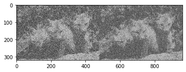

```
2019-11-24 13:25:13: Datset: Set68
  PSNR = 16.65dB, SSIM = 0.6934
```

```python
# -*- coding: utf-8 -*-

# =============================================================================
#  @article{zhang2017beyond,
#    title={Beyond a {Gaussian} denoiser: Residual learning of deep {CNN} for image denoising},
#    author={Zhang, Kai and Zuo, Wangmeng and Chen, Yunjin and Meng, Deyu and Zhang, Lei},
#    journal={IEEE Transactions on Image Processing},
#    year={2017},
#    volume={26},
#    number={7},
#    pages={3142-3155},
#  }
# modified version of the code from https://github.com/cszn/DnCNN
# =============================================================================

# run this to test the model

import argparse
import os, time, datetime
import numpy as np
import torch.nn as nn
import torch.nn.init as init
import torch
from skimage.measure import compare_psnr, compare_ssim
from skimage.io import imread, imsave
import warnings
warnings.filterwarnings('ignore')
%matplotlib inline


def parse_args():
    parser = argparse.ArgumentParser()
    parser.add_argument('--set_dir', default='data/Test1', type=str, help='directory of test dataset')
    parser.add_argument('--set_names', default=['Set68'], help='directory of test dataset')
    parser.add_argument('--sigma', default=47, type=int, help='noise level')
    parser.add_argument('--model_path', default='models/model_000.pth', type=str, help='the model name')
    parser.add_argument('--result_dir', default='results', type=str, help='directory of test dataset')
    parser.add_argument('--save_result', action='store_true', help='save the denoised image')
    return parser.parse_args([])


def log(*args, **kwargs):
     print(datetime.datetime.now().strftime("%Y-%m-%d %H:%M:%S:"), *args, **kwargs)


def save_result(result, path):
    path = path if path.find('.') != -1 else path+'.png'
    ext = os.path.splitext(path)[-1]
    if ext in ('.txt', '.dlm'):
        np.savetxt(path, result, fmt='%2.4f')
    else:
        imsave(path, np.uint8(np.clip(result*255.0, 0, 255)))


def show(x, title=None, cbar=False, figsize=None):
    import matplotlib.pyplot as plt
    plt.figure(figsize=figsize)
    plt.imshow(x, interpolation='nearest', cmap='gray')
    if title:
        plt.title(title)
    if cbar:
        plt.colorbar()
    plt.show()


class DnCNN(nn.Module):

    def __init__(self, depth=17, n_channels=64, image_channels=1, use_bnorm=True, kernel_size=3):
        super(DnCNN, self).__init__()
        kernel_size = 3
        padding = 1
        layers = []
        layers.append(nn.Conv2d(in_channels=image_channels, out_channels=n_channels, kernel_size=kernel_size, padding=padding, bias=True))
        layers.append(nn.ReLU(inplace=True))
        for _ in range(depth-2):
            layers.append(nn.Conv2d(in_channels=n_channels, out_channels=n_channels, kernel_size=kernel_size, padding=padding, bias=False))
            layers.append(nn.BatchNorm2d(n_channels))
            layers.append(nn.ReLU(inplace=True))
        layers.append(nn.Conv2d(in_channels=n_channels, out_channels=image_channels, kernel_size=kernel_size, padding=padding, bias=False))
        self.dncnn = nn.Sequential(*layers)
        self._initialize_weights()

    def forward(self, x):
        y = x
        out = self.dncnn(x)
        return y-out

    def _initialize_weights(self):
        for m in self.modules():
            if isinstance(m, nn.Conv2d):
                init.orthogonal_(m.weight)
                print('init weight')
                if m.bias is not None:
                    init.constant_(m.bias, 0)
            elif isinstance(m, nn.BatchNorm2d):
                init.constant_(m.weight, 1)
                #


                init.constant_(m.bias, 0)


if __name__ == '__main__':

    args = parse_args()

    model = torch.load(args.model_path)
    log('load trained model')

    model.eval()  # evaluation mode

    if torch.cuda.is_available():
        model = model.cuda()

    if not os.path.exists(args.result_dir):
        os.mkdir(args.result_dir)

    for set_cur in args.set_names:

        if not os.path.exists(os.path.join(args.result_dir, set_cur)):
            os.mkdir(os.path.join(args.result_dir, set_cur))
        psnrs = []
        ssims = []

        for im in os.listdir(os.path.join(args.set_dir, set_cur)):
            if im.endswith(".jpg") or im.endswith(".bmp") or im.endswith(".png"):

                x = np.array(imread(os.path.join(args.set_dir, set_cur, im)), dtype=np.float32)/255.0
                np.random.seed(seed=0)  # for reproducibility
                y = x + np.random.normal(0, args.sigma/255.0, x.shape)  # Add Gaussian noise without clipping
                y = y.astype(np.float32)
                y_ = torch.from_numpy(y).view(1, -1, y.shape[0], y.shape[1])

                torch.cuda.synchronize()
                start_time = time.time()
                y_ = y_.cuda()
                x_ = model(y_)  # inference
                x_ = x_.view(y.shape[0], y.shape[1])
                x_ = x_.cpu()
                x_ = x_.detach().numpy().astype(np.float32)
                torch.cuda.synchronize()
                elapsed_time = time.time() - start_time
                print('%10s : %10s : %2.4f second' % (set_cur, im, elapsed_time))

                psnr_x_ = compare_psnr(x, x_)
                ssim_x_ = compare_ssim(x, x_)

                name, ext = os.path.splitext(im)
                show(np.hstack((y, x_)))  # show the image
                save_result(x_, path=os.path.join(args.result_dir, set_cur, name+'_dncnn'+ext))  # save the denoised image
                psnrs.append(psnr_x_)
                ssims.append(ssim_x_)
        psnr_avg = np.mean(psnrs)
        ssim_avg = np.mean(ssims)
        psnrs.append(psnr_avg)
        ssims.append(ssim_avg)
        if args.save_result:
            save_result(np.hstack((psnrs, ssims)), path=os.path.join(args.result_dir, set_cur, 'results.txt'))
        log('Datset: {0:10s} \n  PSNR = {1:2.2f}dB, SSIM = {2:1.4f}'.format(set_cur, psnr_avg, ssim_avg))
```

# NOW WITH FINETUNE MODEL

```
2019-11-24 13:25:46: load trained model
     Set68 : VIKUMAR@TCD.IE_024.png : 0.0469 second
```

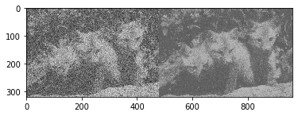

```
2019-11-24 13:25:46: Datset: Set68
  PSNR = 18.07dB, SSIM = 0.6529
```

```python
# -*- coding: utf-8 -*-

# =============================================================================
#  @article{zhang2017beyond,
#    title={Beyond a {Gaussian} denoiser: Residual learning of deep {CNN} for image denoising},
#    author={Zhang, Kai and Zuo, Wangmeng and Chen, Yunjin and Meng, Deyu and Zhang, Lei},
#    journal={IEEE Transactions on Image Processing},
#    year={2017},
#    volume={26},
#    number={7},
#    pages={3142-3155},
#  }
# modified version of the code from https://github.com/cszn/DnCNN
# =============================================================================

# run this to test the model

import argparse
import os, time, datetime
import numpy as np
import torch.nn as nn
import torch.nn.init as init
import torch
from skimage.measure import compare_psnr, compare_ssim
from skimage.io import imread, imsave
import warnings
warnings.filterwarnings('ignore')
%matplotlib inline


def parse_args():
    parser = argparse.ArgumentParser()
    parser.add_argument('--set_dir', default='data/Test1', type=str, help='directory of test dataset')
    parser.add_argument('--set_names', default=['Set68'], help='directory of test dataset')
    parser.add_argument('--sigma', default=47, type=int, help='noise level')
    parser.add_argument('--model_path', default='models/model_001.pth', type=str, help='the model name')
    parser.add_argument('--result_dir', default='results', type=str, help='directory of test dataset')
    parser.add_argument('--save_result', action='store_true', help='save the denoised image')
    return parser.parse_args([])


def log(*args, **kwargs):
     print(datetime.datetime.now().strftime("%Y-%m-%d %H:%M:%S:"), *args, **kwargs)


def save_result(result, path):
    path = path if path.find('.') != -1 else path+'.png'
    ext = os.path.splitext(path)[-1]
    if ext in ('.txt', '.dlm'):
        np.savetxt(path, result, fmt='%2.4f')
    else:
        imsave(path, np.uint8(np.clip(result*255.0, 0, 255)))


def show(x, title=None, cbar=False, figsize=None):
    import matplotlib.pyplot as plt
    plt.figure(figsize=figsize)
    plt.imshow(x, interpolation='nearest', cmap='gray')
    if title:
        plt.title(title)
    if cbar:
        plt.colorbar()
    plt.show()


class DnCNN(nn.Module):

    def __init__(self, depth=17, n_channels=64, image_channels=1, use_bnorm=True, kernel_size=3):
        super(DnCNN, self).__init__()
        kernel_size = 3
        padding = 1
        layers = []
        layers.append(nn.Conv2d(in_channels=image_channels, out_channels=n_channels, kernel_size=kernel_size, padding=padding, bias=True))
        layers.append(nn.ReLU(inplace=True))
        for _ in range(depth-2):
            layers.append(nn.Conv2d(in_channels=n_channels, out_channels=n_channels, kernel_size=kernel_size, padding=padding, bias=False))
            layers.append(nn.BatchNorm2d(n_channels))
            layers.append(nn.ReLU(inplace=True))
        layers.append(nn.Conv2d(in_channels=n_channels, out_channels=image_channels, kernel_size=kernel_size, padding=padding, bias=False))
        self.dncnn = nn.Sequential(*layers)
        self._initialize_weights()

    def forward(self, x):
        y = x
        out = self.dncnn(x)
        return y-out

    def _initialize_weights(self):
        for m in self.modules():
            if isinstance(m, nn.Conv2d):
                init.orthogonal_(m.weight)
                print('init weight')
                if m.bias is not None:
                    init.constant_(m.bias, 0)
            elif isinstance(m, nn.BatchNorm2d):
                init.constant_(m.weight, 1)
                #


                init.constant_(m.bias, 0)


if __name__ == '__main__':

    args = parse_args()

    model = torch.load(args.model_path)
    log('load trained model')

    model.eval()  # evaluation mode

    if torch.cuda.is_available():
        model = model.cuda()

    if not os.path.exists(args.result_dir):
        os.mkdir(args.result_dir)

    for set_cur in args.set_names:

        if not os.path.exists(os.path.join(args.result_dir, set_cur)):
            os.mkdir(os.path.join(args.result_dir, set_cur))
        psnrs = []
        ssims = []

        for im in os.listdir(os.path.join(args.set_dir, set_cur)):
            if im.endswith(".jpg") or im.endswith(".bmp") or im.endswith(".png"):

                x = np.array(imread(os.path.join(args.set_dir, set_cur, im)), dtype=np.float32)/255.0
                np.random.seed(seed=0)  # for reproducibility
                y = x + np.random.normal(0, args.sigma/255.0, x.shape)  # Add Gaussian noise without clipping
                y = y.astype(np.float32)
                y_ = torch.from_numpy(y).view(1, -1, y.shape[0], y.shape[1])

                torch.cuda.synchronize()
                start_time = time.time()
                y_ = y_.cuda()
                x_ = model(y_)  # inference
                x_ = x_.view(y.shape[0], y.shape[1])
                x_ = x_.cpu()
                x_ = x_.detach().numpy().astype(np.float32)
                torch.cuda.synchronize()
                elapsed_time = time.time() - start_time
                print('%10s : %10s : %2.4f second' % (set_cur, im, elapsed_time))

                psnr_x_ = compare_psnr(x, x_)
                ssim_x_ = compare_ssim(x, x_)
                name, ext = os.path.splitext(im)
                show(np.hstack((y, x_)))  # show the image
                save_result(x_, path=os.path.join(args.result_dir, set_cur, name+'_dncnn'+ext))  # save the denoised image
                psnrs.append(psnr_x_)
                ssims.append(ssim_x_)
        psnr_avg = np.mean(psnrs)
        ssim_avg = np.mean(ssims)
        psnrs.append(psnr_avg)
        ssims.append(ssim_avg)
        if args.save_result:
            save_result(np.hstack((psnrs, ssims)), path=os.path.join(args.result_dir, set_cur, 'results.txt'))
        log('Datset: {0:10s} \n  PSNR = {1:2.2f}dB, SSIM = {2:1.4f}'.format(set_cur, psnr_avg, ssim_avg))
```

# 2.e) Modify the network to output the estimated noise

(Residual image in Fig.1) instead of the clean image. Generate noise from YourEmail_XXX.png by your finetuned network and save it as a grayscale image centered around intensity 127 named YourEmail_XXX_noise.png. Report the standard deviation of the noise in this image.

```
2019-11-24 14:35:42: load trained model
Mean: [[127.0009491]]
Standard Deviation: [[0.18384454]]
     Set68 : VIKUMAR@TCD.IE_024.png : 0.1094 second
```

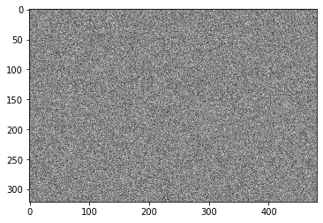

[figure not shown]

```
2019-11-24 14:35:43: Datset: Set68
  PSNR = -58.33dB, SSIM = 0.0000
```

```python
# -*- coding: utf-8 -*-

# =============================================================================
#  @article{zhang2017beyond,
#    title={Beyond a {Gaussian} denoiser: Residual learning of deep {CNN} for image denoising},
#    author={Zhang, Kai and Zuo, Wangmeng and Chen, Yunjin and Meng, Deyu and Zhang, Lei},
#    journal={IEEE Transactions on Image Processing},
#    year={2017},
#    volume={26},
#    number={7},
#    pages={3142-3155},
#  }
# modified version of the code from https://github.com/cszn/DnCNN
# =============================================================================

# run this to test the model

import argparse
import os, time, datetime
import numpy as np
import torch.nn as nn
import torch.nn.init as init
import torch
from skimage.measure import compare_psnr, compare_ssim
from skimage.io import imread, imsave
import matplotlib.pyplot as plt
import cv2
import warnings
warnings.filterwarnings('ignore')
%matplotlib inline


def parse_args():
    parser = argparse.ArgumentParser()
    parser.add_argument('--set_dir', default='data/Test1', type=str, help='directory of test dataset')
    parser.add_argument('--set_names', default=['Set68'], help='directory of test dataset')
    parser.add_argument('--sigma', default=47, type=int, help='noise level')
    parser.add_argument('--model_path', default='models/model_001.pth', type=str, help='the model name')
    parser.add_argument('--result_dir', default='results', type=str, help='directory of test dataset')
    parser.add_argument('--save_result', action='store_true', help='save the denoised image')
    return parser.parse_args([])


def log(*args, **kwargs):
     print(datetime.datetime.now().strftime("%Y-%m-%d %H:%M:%S:"), *args, **kwargs)


def save_result(result, path):
    path = path if path.find('.') != -1 else path+'.png'
    ext = os.path.splitext(path)[-1]
    if ext in ('.txt', '.dlm'):
        np.savetxt(path, result, fmt='%2.4f')
    else:
        imsave(path, np.uint8(np.clip(result*255.0, 0, 255)))


def show(x, title=None, cbar=False, figsize=None):
    import matplotlib.pyplot as plt
    plt.figure(figsize=figsize)
    plt.imshow(x, interpolation='nearest', cmap='gray')
    if title:
        plt.title(title)
    if cbar:
        plt.colorbar()
    plt.show()


class DnCNN(nn.Module):

    def __init__(self, depth=17, n_channels=64, image_channels=1, use_bnorm=True, kernel_size=3):
        super(DnCNN, self).__init__()
        kernel_size = 3
        padding = 1
        layers = []
        layers.append(nn.Conv2d(in_channels=image_channels, out_channels=n_channels, kernel_size=kernel_size, padding=padding, bias=True))
        layers.append(nn.ReLU(inplace=True))
        for _ in range(depth-2):
            layers.append(nn.Conv2d(in_channels=n_channels, out_channels=n_channels, kernel_size=kernel_size, padding=padding, bias=False))
            layers.append(nn.BatchNorm2d(n_channels))
            layers.append(nn.ReLU(inplace=True))
        layers.append(nn.Conv2d(in_channels=n_channels, out_channels=image_channels, kernel_size=kernel_size, padding=padding, bias=False))
        self.dncnn = nn.Sequential(*layers)
        self._initialize_weights()

    def forward(self, x):
        y = x
        out = self.dncnn(x)
        return y-out

    def _initialize_weights(self):
        for m in self.modules():
            if isinstance(m, nn.Conv2d):
                init.orthogonal_(m.weight)
                print('init weight')
                if m.bias is not None:
                    init.constant_(m.bias, 0)
            elif isinstance(m, nn.BatchNorm2d):
                init.constant_(m.weight, 1)
                #


                init.constant_(m.bias, 0)


if __name__ == '__main__':

    args = parse_args()

    model = torch.load(args.model_path)
    log('load trained model')

    model.eval()  # evaluation mode

    if torch.cuda.is_available():
        model = model.cuda()

    if not os.path.exists(args.result_dir):
        os.mkdir(args.result_dir)

    for set_cur in args.set_names:

        if not os.path.exists(os.path.join(args.result_dir, set_cur)):
            os.mkdir(os.path.join(args.result_dir, set_cur))
        psnrs = []
        ssims = []

        for im in os.listdir(os.path.join(args.set_dir, set_cur)):
            if im.endswith(".jpg") or im.endswith(".bmp") or im.endswith(".png"):

                x = np.array(imread(os.path.join(args.set_dir, set_cur, im)), dtype=np.float32)/255.0
                np.random.seed(seed=0)  # for reproducibility
                y = np.random.normal(0, args.sigma/255.0, x.shape)
                y = y.astype(np.float32)
                y = y + 127

                for i in range(x.shape[0]):
                    for j in range(x.shape[1]):
                        if y[i][j] > 255:
                            y[i][j]=255
                        elif y[i][j]<0:
                            y[i][j]=0

                plt.imshow(y,cmap='gray')
                mean,std = cv2.meanStdDev(y)
                plt.savefig('./vikumar@TCD.IE_024_noise.png')
                print("Mean:",mean)
                print("Standard Deviation:",std)
                y_ = torch.from_numpy(y).view(1, -1, y.shape[0], y.shape[1])

                torch.cuda.synchronize()
                start_time = time.time()
                y_ = y_.cuda()
                x_ = model(y_)  # inference
                x_ = x_.view(y.shape[0], y.shape[1])
                x_ = x_.cpu()
                x_ = x_.detach().numpy().astype(np.float32)
                torch.cuda.synchronize()
                elapsed_time = time.time() - start_time
                print('%10s : %10s : %2.4f second' % (set_cur, im, elapsed_time))

                psnr_x_ = compare_psnr(x, x_)
                ssim_x_ = compare_ssim(x, x_)
                name, ext = os.path.splitext(im)
                show(np.hstack((y, x_)))  # show the image
                save_result(x_, path=os.path.join(args.result_dir, set_cur, name+'_dncnn'+ext))  # save the denoised image
                psnrs.append(psnr_x_)
                ssims.append(ssim_x_)
        psnr_avg = np.mean(psnrs)
        ssim_avg = np.mean(ssims)
        psnrs.append(psnr_avg)
        ssims.append(ssim_avg)
        if args.save_result:
            save_result(np.hstack((psnrs, ssims)), path=os.path.join(args.result_dir, set_cur, 'results.txt'))
        log('Datset: {0:10s} \n  PSNR = {1:2.2f}dB, SSIM = {2:1.4f}'.format(set_cur, psnr_avg, ssim_avg))
```

# 3) Semantic segmentation

# 3.a) Briefly explain:

i) How FCN upsamples predictions to match the original image size. ii) How had the authors improved the coarse predictions produced by the deepest layer.

# i) How FCN upsamples predictions to match the original image size?

FCN when propagate though multiple alternated convolutional and pooling layer, output feature map resolution is down sampled. As a result FCN direct prediction is of low resolution having fuzzy boundaries of object. The Upsampling layer is a simple layer with no weights which will double the input dimension and generate model with convolutional layer. It works by repeating the rows and columns of the input. Dense prediction is achieved by sampling the output of the last convolution layer and computing pixel-wise loss.

# ii) How had the authors improved the coarse predictions produced by the deepest layer?

The researcher has converted classification net into convolutional nets that produce coarse output maps. He then reinterpreted the classification nets as fully convolutional yields output maps of any size of the input. Output dimension is reduced by sub sampling. This classification nets subsample keeping filter small and computationally reasonable. This coarsens the output of a fully convolutional version of these nets, reducing it from the size of the input by a factor equal to the pixel stride of the receptive fields of the output units. The second method is shift-and-stitch is filter rarefaction. In this method dense predictions is obtained from coarse outputs by stitching together output from shifted versions of the input. The yet another method that can be used is interpolation where we connect coarse outputs to dense pixels

# 3.b Download YourEmail.png and take a class index assigned to you from classes.csv. Modify segmentation.py so that you predict segmentation mask of this class (by FCN model) on the image given to you and highlight prediction via red mask blended with the original image. Submit this image as YourEmail_predicted.png.

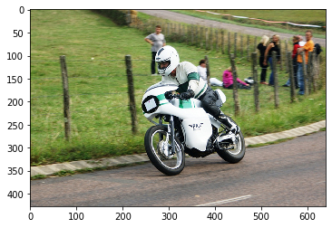

```
torch.Size([1, 21, 427, 640])
[ 0 14 15]
```

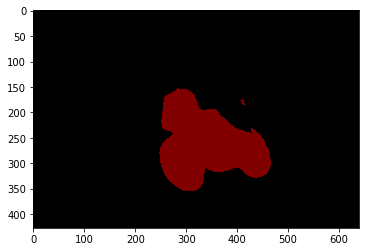

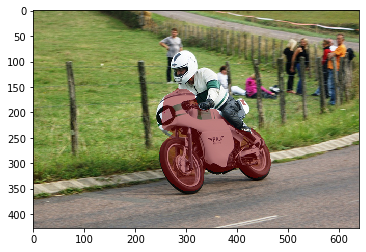

```python
# -*- coding: utf-8 -*-
"""
Based on code from
    https://colab.research.google.com/github/spmallick/learnopencv/blob/master/PyTorch-Segmentation-torchvision/intro-seg.ipynb
"""

from PIL import Image
import matplotlib.pyplot as plt
import torch
from torchvision import models
import numpy as np
import torchvision.transforms as T
import cv2


def decode_segmap(image, nc):

  label_colors = np.array([(0, 0, 0),  # 0=background
               # 1=aeroplane, 2=bicycle, 3=bird, 4=boat, 5=bottle
               (128, 0, 0), (0, 128, 0), (128, 128, 0), (0, 0, 128), (128, 0, 128),
               # 6=bus, 7=car, 8=cat, 9=chair, 10=cow
               (0, 128, 128), (128, 128, 128), (64, 0, 0), (192, 0, 0), (64, 128, 0),
               # 11=dining table, 12=dog, 13=horse, 14=motorbike, 15=person
               (192, 128, 0), (64, 0, 128), (192, 0, 128), (64, 128, 128), (192, 128, 128),
               # 16=potted plant, 17=sheep, 18=sofa, 19=train, 20=tv/monitor
               (0, 64, 0), (128, 64, 0), (0, 192, 0), (128, 192, 0), (0, 64, 128)])

  r = np.zeros_like(image).astype(np.uint8)
  g = np.zeros_like(image).astype(np.uint8)
  b = np.zeros_like(image).astype(np.uint8)

  for l in range(0, nc):
      idx = image == 14
      r[idx] = label_colors[l, 0]
      g[idx] = label_colors[l, 1]
      b[idx] = label_colors[l, 2]

  rgb = np.stack([b, r, r], axis=2)
  return rgb


def apply_mask(im, im_pred):
    """
    Overlays the predicted class labels onto an image using the alpha channel.
    This function assumes that the background label is the black color.
    This function is provided as an inspiration for the masking function you should write.
    """
    r_channel, g_channel, b_channel = cv2.split(im_pred)
    alpha_channel = 127 * np.ones(b_channel.shape, dtype=b_channel.dtype)
    # Make background pixels fully transparent
    alpha_channel -= 127 * np.all(im_pred == np.array([0, 0, 0]), axis=2).astype(b_channel.dtype)
    im_pred = cv2.merge((r_channel, g_channel, b_channel, alpha_channel))
    mask = Image.fromarray(im_pred, mode='RGBA')
    masked_img = Image.fromarray(im)
    masked_img.paste(mask, box=None, mask=mask)
    return np.array(masked_img)

# define the model
fcn = models.segmentation.fcn_resnet101(pretrained=True).eval()

# load an image
img = Image.open('./VIKUMAR@TCD.IE.png')
plt.imshow(img); plt.show()

# transform the image
trf = T.Compose([T.ToTensor(),
                 T.Normalize(mean = [0.485, 0.456, 0.406],
                             std = [0.229, 0.224, 0.225])])
inp = trf(img).unsqueeze(0)

# pass the input through the net
out = fcn(inp)['out']
print (out.shape)

# calculate labels
om = torch.argmax(out.squeeze(), dim=0).detach().cpu().numpy()
print (np.unique(om))

# show segmentation output
rgb = decode_segmap(om,21)
plt.imshow(rgb); plt.show()
abc = apply_mask(np.array(img),np.array(rgb))
plt.imshow(abc); plt.show()
im=Image.fromarray(abc)
im.save("VIKUMAR@TCD.IE_Predicted.png")
```

# 3.c) Decode the groundtruth image YourEmail_mask.png and calculate intersection over union (IOU) with the prediction for the class assigned to you. Report IOU in file YourEmail_iou.csv.

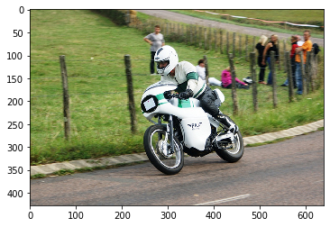

```
torch.Size([1, 21, 427, 640])
[ 0 14 15]
```

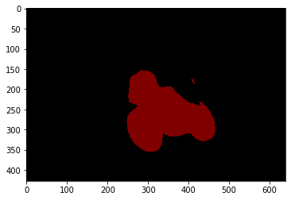

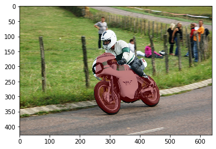

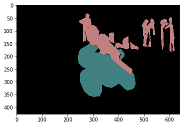

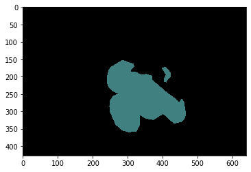

```
0.2991937575143214
```

```python
# -*- coding: utf-8 -*-
"""
Based on code from
    https://colab.research.google.com/github/spmallick/learnopencv/blob/master/PyTorch-Segmentation-torchvision/intro-seg.ipynb
"""

from PIL import Image
import matplotlib.pyplot as plt
import torch
from torchvision import models
import numpy as np
import torchvision.transforms as T
import cv2


def decode_segmap(image, nc):

  label_colors = np.array([(0, 0, 0),  # 0=background
               # 1=aeroplane, 2=bicycle, 3=bird, 4=boat, 5=bottle
               (128, 0, 0), (0, 128, 0), (128, 128, 0), (0, 0, 128), (128, 0, 128),
               # 6=bus, 7=car, 8=cat, 9=chair, 10=cow
               (0, 128, 128), (128, 128, 128), (64, 0, 0), (192, 0, 0), (64, 128, 0),
               # 11=dining table, 12=dog, 13=horse, 14=motorbike, 15=person
               (192, 128, 0), (64, 0, 128), (192, 0, 128), (64, 128, 128), (192, 128, 128),
               # 16=potted plant, 17=sheep, 18=sofa, 19=train, 20=tv/monitor
               (0, 64, 0), (128, 64, 0), (0, 192, 0), (128, 192, 0), (0, 64, 128)])

  r = np.zeros_like(image).astype(np.uint8)
  g = np.zeros_like(image).astype(np.uint8)
  b = np.zeros_like(image).astype(np.uint8)

  for l in range(0, nc):
      idx = image == 14
      r[idx] = label_colors[l, 0]
      g[idx] = label_colors[l, 1]
      b[idx] = label_colors[l, 2]

  rgb = np.stack([b, r, r], axis=2)
  return rgb


def apply_mask(im, im_pred):
    """
    Overlays the predicted class labels onto an image using the alpha channel.
    This function assumes that the background label is the black color.
    This function is provided as an inspiration for the masking function you should write.
    """
    r_channel, g_channel, b_channel = cv2.split(im_pred)
    alpha_channel = 127 * np.ones(b_channel.shape, dtype=b_channel.dtype)
    # Make background pixels fully transparent
    alpha_channel -= 127 * np.all(im_pred == np.array([0, 0, 0]), axis=2).astype(b_channel.dtype)
    im_pred = cv2.merge((r_channel, g_channel, b_channel, alpha_channel))
    mask = Image.fromarray(im_pred, mode='RGBA')
    masked_img = Image.fromarray(im)
    masked_img.paste(mask, box=None, mask=mask)
    return np.array(masked_img)

# define the model
fcn = models.segmentation.fcn_resnet101(pretrained=True).eval()

# load an image
img = Image.open('./VIKUMAR@TCD.IE.png')
plt.imshow(img); plt.show()

# transform the image
trf = T.Compose([T.ToTensor(),
                 T.Normalize(mean = [0.485, 0.456, 0.406],
                             std = [0.229, 0.224, 0.225])])
inp = trf(img).unsqueeze(0)

# pass the input through the net
out = fcn(inp)['out']
print (out.shape)

# calculate labels
om = torch.argmax(out.squeeze(), dim=0).detach().cpu().numpy()
print (np.unique(om))

# show segmentation output
rgb = decode_segmap(om,21)
plt.imshow(rgb); plt.show()
abc = apply_mask(np.array(img),np.array(rgb))
plt.imshow(abc); plt.show()
im=Image.fromarray(abc)
#im.save("VIKUMAR@TCD.IE_Predicted.png")


mask=Image.open('VIKUMAR@TCD.IE_mask.png')
plt.imshow(mask); plt.show()
pixels=mask.load()
for i in range (np.array(mask).shape[1]):
  for j in range (np.array(mask).shape[0]):
    if not (pixels[i,j]==(64, 128, 128)): #Change based on the class values from the top
      pixels[i,j]=(0,0,0)
plt.imshow(mask); plt.show()
intersection = np.sum(np.logical_and(rgb,np.array(mask)))
union = np.sum( np.logical_or(rgb,np.array(mask)))
print(intersection/union)
```